# company Nearly New Nautical Sales

### Michael Ben Ali

### Data Analyst

#### Marketing Department

#### Thursday 28th February 2022

# Introduction : Nearly New Nautical Sales

## Objective : Boosting our website views by next year!

We have been provided plenty of data from our website with the views from the past 7 days (around 10,000 boats). Our objective is to look at the trend of the most view boats to improve the average number of views to 75% more this year. With those data, we are gonna to notify boat sellers on our website and advertise so we can improve and stay at the top of the market trend.

Let's have a quick look at the data, we were provided so we can eventually make some assumptions :

Here data from the top 5 boats in terms of views:

|  | Boat Type | Manufacturer | Year Built | Length | Width | Material | Location | Number of views last 7 days | Price Euro (1000K) | Used or New | Motor Type | Decade |
| --- | --- | --- | --- | --- | --- | --- | --- | --- | --- | --- | --- | --- |
| 9580 | Motor Yacht | Bayliner power boats | 1992 | 7.70 | 2.46 | Plastic | Switzerland | 3263 | 14.304 | Used | Unleaded | 1990 |
| 8723 | Hardtop | Princess power boats | 1979 | 11.12 | 3.88 | GRP | Switzerland | 2432 | 33.600 | Used | Diesel | 1970 |
| 6211 | Bowrider,Motor Yacht,Sport Boat | Windy power boats | 2002 | 12.35 | 3.48 | GRP | Switzerland | 2261 | 120.864 | Used | Diesel | 2000 |
| 3700 | Hardtop | Pershing power boats | 2009 | 20.30 | 5.20 | GRP | Germany | 2154 | 949.000 | Used | Diesel | 2000 |
| 308 | Sport Boat | Sea Ray power boats | 1993 | 6.14 | 2.34 | Plastic | Switzerland | 2026 | 19.104 | Used | Unleaded | 1990 |

We were ask to respond to some question :

1) Is it the most expensive boats that get the most views ?

2) Are there common features among the most viewed boats ? Seing the data preview, we will add the following exploration :

```
- Are used boat more seen than band new one ?
- From which country are the most view boat ?
- Is there a prefered material for most viewed boat ?
- How old are used boat that are more seen ?
```

# Are expensive boats the most viewed ?

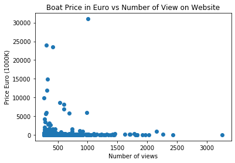

```
Here we can easily agree that the most view boat aren't the most expensive ones.
After this lets find if there is commun feature between most viewed boat.
```

# Are used boat more seen than brand new one ?

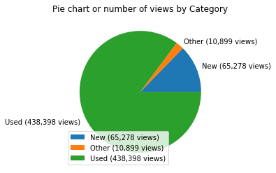

```
Here we can clearly see that most views are from used boat.
```

# From which country are the most view boat ?

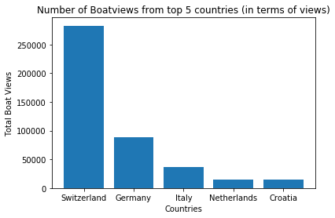

```
Switzerland, Germany, Italy, Netherlands and Croatia are the country with the most views.
```

# Is there a prefered material for most viewed boat ?

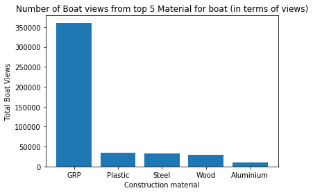

[output not shown]

# How old are used boat that are more seen ?

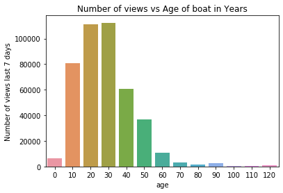

```
Here we can see that boats betweed 10 to 40 years old have a big number of views.
      Mostly boats between 20 to 30 years old are the one which tend to be the most seen.
```

# Conclusion

We have answered the following question :

**Is it the most expensive boats that get the most views ?**

Unfortunaly, Not at all.

**Are used boat more seen than brand new one ?**

Of course, as expected from a website that advertise used boat most of them are used.

**From which country are the most view boat ?**

Switzerland, Germany and Italy are the top 3 countries with the most views.

**Is there a prefered material for most viewed boat ?**

GRP is the far prefered material.

**How old are used boat that are more seen ?**

Between 20 and 30 years old.